# Data Visualization

Group C

September 27, 2019

## Theme Setting:

A custom theme is created to be used throughout the visualizations. The main colors are defined beforehand to avoid hard coding.

```r
# Defining the main colors:
fill_color = '#C7522B'
decoration_color = '#686868'
main1_color = '#61795B'
main2_color = '#9DB469'

#Create a theme we can apply everywhere
group_c_theme<-theme_bw() + theme(
  panel.grid.major = element_blank(),
  panel.grid.minor = element_blank(),
  axis.title = element_text(size = 10, hjust = 0.5, color = decoration_color),
  axis.text = element_text(colour = decoration_color, size = 8),
  axis.ticks = element_blank(),
  axis.line = element_line(colour = decoration_color, size=0.3, linetype = '1F'),
  panel.border = element_blank(),
  panel.grid = element_blank(),
  strip.text = element_text(size = 12, color = decoration_color),
  strip.background =element_blank(),
  legend.position="None",
  plot.background = element_rect(fill = "#f5f5f2", color = NA),
  panel.background = element_rect(fill = "#f5f5f2", color = NA),
  plot.title = element_text(size = 26, hjust = 0.5,  color = decoration_color)
)

#Now we set the new defined theme to the default option
theme_set(group_c_theme)
```

# An investigation into US citizen ‘Andy Dufresne’ conducted by the FBI, with specific focus on American Express blue card expenditures

## Exploratory Data Analysis:

We first became aware of the suspect when our partners at American Express flagged an anomalously large transaction on his American Express blue card. We proceeded to pull his annual data in order to investigate for further suspicious behaviour.

The first step is to get a summary of the data as well as information regarding the data types. This sets the stage for all visualizations, as a good understanding of the data at hand allows for proper investigation.

```r
head(df)
```

```
##          Date                  Merchant Amount        Country
## 1: 2016-01-05   SALLMANN YANG & ALAMEDA 243.75  United States
## 2: 2016-01-06                    ITUNES   1.99  United States
## 3: 2016-01-07                 BA.COM UK 545.01 United Kingdom
## 4: 2016-01-12             FITNESSKEEPER  39.99  United States
## 5: 2016-01-20 AMAZON UK MARKETPLACE APE  20.78     Luxembourg
## 6: 2016-01-21 AMAZON UK MARKETPLACE APE 106.65     Luxembourg
##                  Category       Subcategory row.names
## 1:      Business Services  Banking Services         1
## 2: Merchandise & Supplies Internet Purchase         2
## 3:                 Travel           Airline         3
## 4: Merchandise & Supplies Internet Purchase         4
## 5: Merchandise & Supplies Internet Purchase         5
## 6: Merchandise & Supplies Internet Purchase         6
```

```r
summary(df)
```

```
##       Date                       Merchant             Amount
##  Min.   :2016-01-05 00:00:00   Length:110         Min.   :-1510.13
##  1st Qu.:2016-02-27 12:00:00   Class :character   1st Qu.:   14.80
##  Median :2016-06-13 12:00:00   Mode  :character   Median :   57.88
##  Mean   :2016-07-01 16:08:43                      Mean   :  398.95
##  3rd Qu.:2016-10-26 00:00:00                      3rd Qu.:  243.98
##  Max.   :2016-12-30 00:00:00                      Max.   :17274.68
##    Country            Category         Subcategory          row.names
##  Length:110         Length:110         Length:110         Min.   :  1.00
##  Class :character   Class :character   Class :character   1st Qu.: 28.25
##  Mode  :character   Mode  :character   Mode  :character   Median : 55.50
##                                                           Mean   : 55.50
##                                                           3rd Qu.: 82.75
##                                                           Max.   :110.00
```

```r
str(df)
```

```
## Classes 'data.table' and 'data.frame':   110 obs. of  7 variables:
##  $ Date       : POSIXct, format: "2016-01-05" "2016-01-06" ...
##  $ Merchant   : chr  "SALLMANN YANG & ALAMEDA" "ITUNES" "BA.COM UK" "FITNESSKEEPER" ...
##  $ Amount     : num  243.75 1.99 545.01 39.99 20.78 ...
##  $ Country    : chr  "United States" "United States" "United Kingdom" "United States" ...
##  $ Category   : chr  "Business Services" "Merchandise & Supplies" "Travel" "Merchandise & Supplies" ...
##  $ Subcategory: chr  "Banking Services" "Internet Purchase" "Airline" "Internet Purchase" ...
##  $ row.names  : int  1 2 3 4 5 6 7 8 9 10 ...
##  - attr(*, ".internal.selfref")=<externalptr>
```

## Spendings:

Starting this section, we take a look at Andy’s expenses. The first chart we create plots time vs money spent. This is done in order to assess the full shape of the data, and to see if the large transaction - that of a Nissan automobile in December of the dataset - represented an outlier or fit with the suspect’s usual purchasing activity. This chart reveals that the purchase was indeed an outlier.

To place this outlier in perspective we create a cumulative chart. This helps decrease the effect of the outlier on the data, and allows a clearer analysis of the rest of the year’s purchasing data.

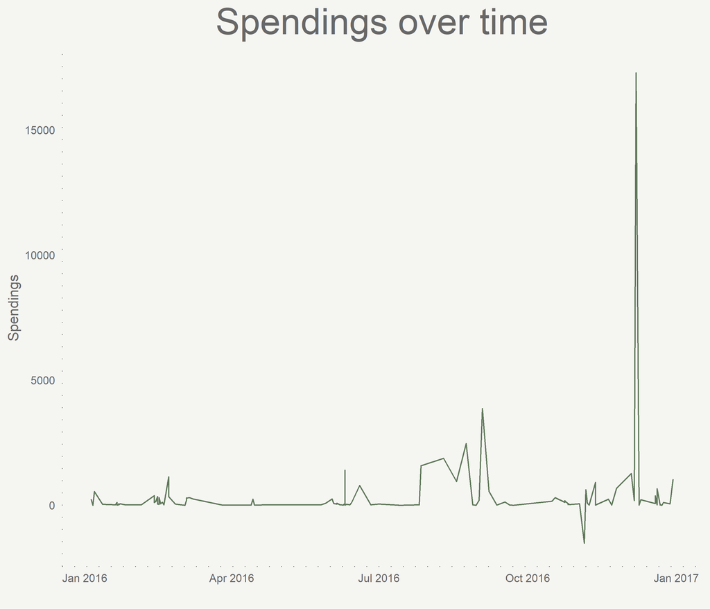

```r
# Spendings per time
(amount_vs_time <- ggplot(df, aes(x=Date, y=Amount)) + geom_line(color = main1_color)
  + labs(title = "Spendings over time")+ xlab(""))+ ylab("Spendings")
```

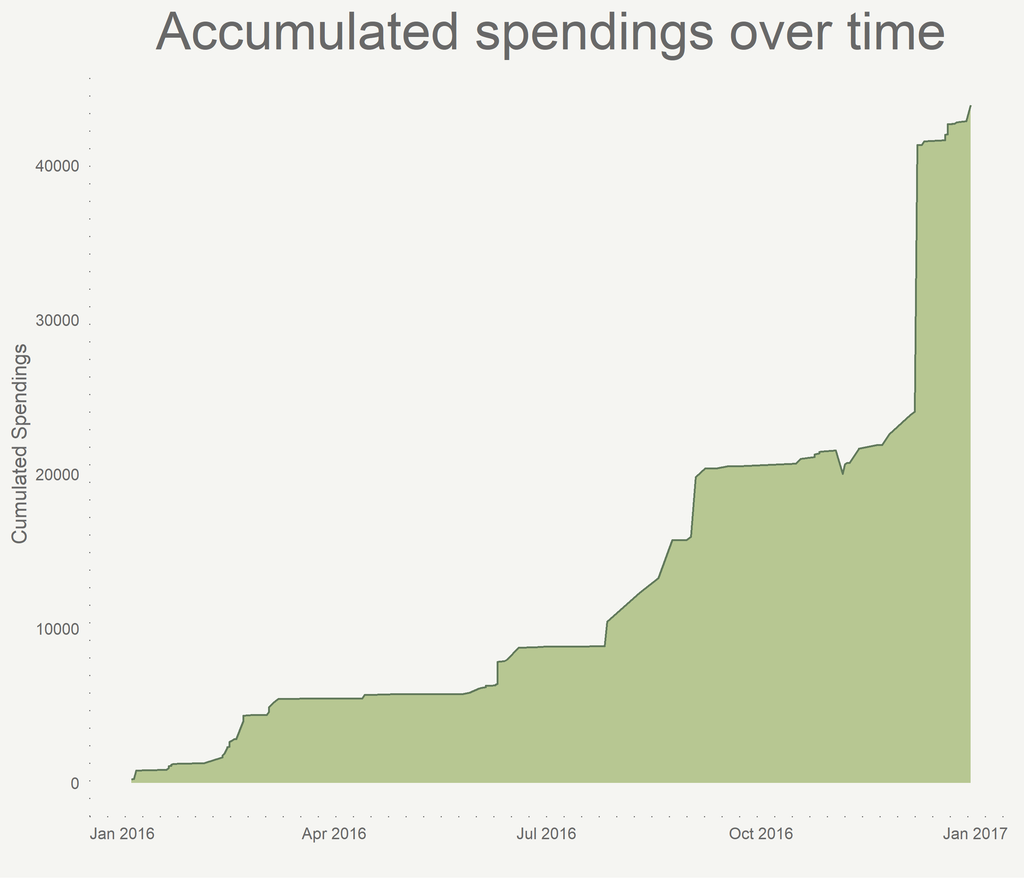

```r
# Accumulated spendings over the year
(cumul_amount_vs_time <- ggplot(df, aes(x=Date)) + geom_ribbon(aes(ymin = 0, ymax = cumsum(Amount)),
                                                               fill = main2_color, alpha = 0.7) +
          geom_line(aes(y = cumsum(Amount)),color = main1_color)+
          labs(title = "Accumulated spendings over time") + xlab("") + ylab("Cumulated Spendings"))
```

In order to dig deeper into the suspect’s behaviour, an analysis of his purchased items is necessary; to see if they were in keeping with that of a citizen matching his profile. A treemap is assembled, showing that (taking account of the outlier) the majority of his purchases were on mundane everyday items one would expect from a law-abiding citizen. The only suspicious aspect revolved around an unusually large travel spend over the year.

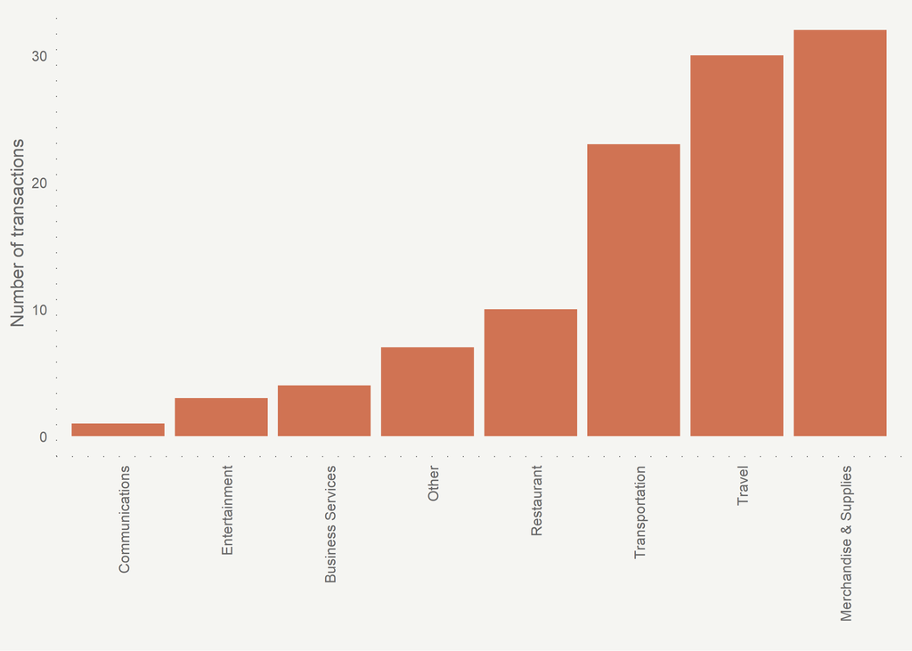

```r
# Builduing a simple barplot overviewing the number of purchases per category

ggplot(df, aes(x=Category)) + geom_bar(stat='count', fill = fill_color, alpha = 0.8)+ theme(axis.text.x = element_text(angle = 90, hjust = 1)) + ylab("Number of transactions") + xlab("") + scale_x_discrete(limits = c("Communications", "Entertainment", "Business Services", "Other", "Restaurant", "Transportation", "Travel", "Merchandise & Supplies"))
```

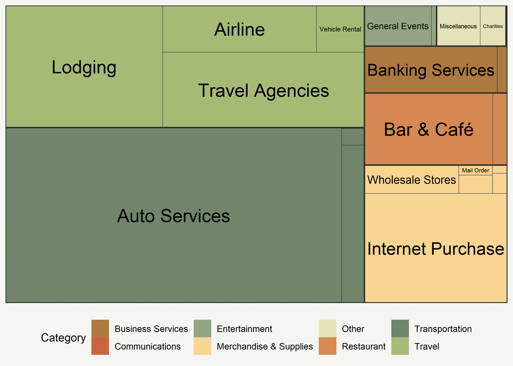

```r
# Calculating total amount of spendings per category and subcategory
df_treemap <- df[,list(Total_amount = sum(Amount)), by = c('Category', 'Subcategory')]

#  Creating a treemap with custom colours divided by spendings per category and subcategory
(categories_treemap <- ggplot(df_treemap, aes(area=Total_amount, label=Subcategory,
        fill = Category, subgroup=Category, subgroup2 = Subcategory)) + geom_treemap(alpha = 0.9)
        + geom_treemap_text(place='centre')) +
        geom_treemap_subgroup_border(color = "#303030", size = 2 ) +
        geom_treemap_subgroup2_border(color = "#303030", size = 0.5) +
        theme(legend.position="bottom",
              legend.background = element_rect(fill = "#f5f5f2", color = NA)) +
        scale_fill_manual(values = c("#A46B2C", "#C7522B", "#8A9B77", "#F7D086",
                                     "#E2E0B3", "#D07D41", "#61795B", "#9DB469"))
```

## Auto expenses - Tufte Chart:

We take a closer look at Andy’s expenses on a daily level, excluding abnomal auto expenses. We begin to track the suspect’s movements around the US, UK and Europe in order to discover if there has been any suspicious increases.

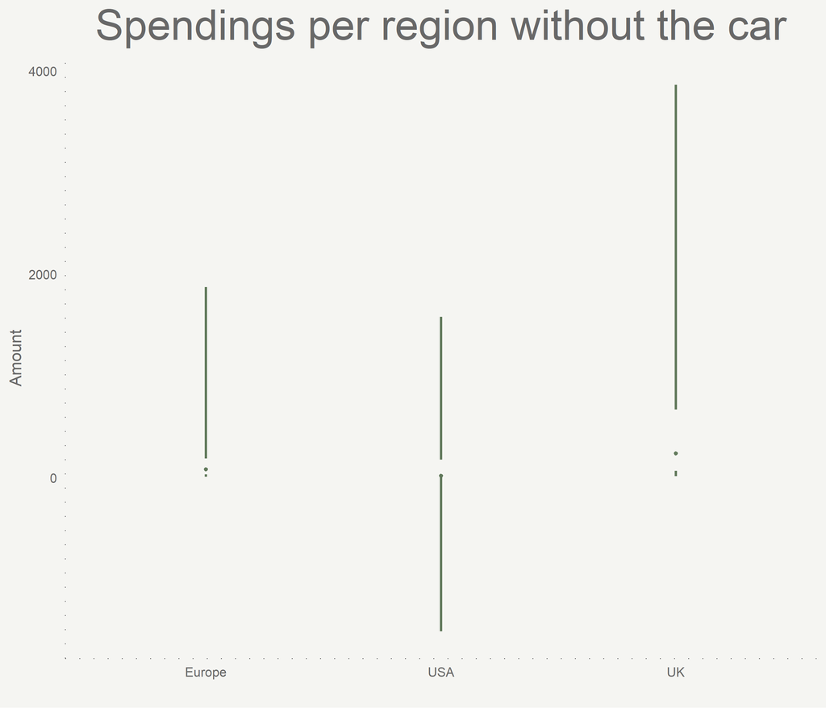

```r
### Transforming the data for Tufte chart

df_tufte <- df %>%
          filter(Subcategory != "Auto Services") %>%
          mutate(Country_group = derivedFactor(
            "Europe" = Country %in% c('Luxembourg', 'Germany', 'Sweden', 'Denmark', 'Netherlands', 'Ireland',
                            'Czech Republic','Portugal','France'),
            "USA" = Country %in% c('United States'),
            "UK" = Country %in% c('United Kingdom')
            ))


# Tufte boxplot without outlier purchase of the car
ggplot(df_tufte, aes(Country_group,Amount)) +
  geom_tufteboxplot(outlier.colour="transparent", size=0.7, color=main1_color) +
  labs(title = 'Spendings per region without the car') + xlab("")
```

## Expenses over time:

The data is presented in a waffle chart.

```r
##### WAFFLE

# Transforming data to get percentage of spending per category and quarter
seasonal_data <- df %>%
  mutate(quarter = quarters(Date))

business_services <- seasonal_data %>%
  filter(Category == 'Business Services') %>%
  group_by(quarter) %>%
  summarise(num_obs = n()) %>%
  mutate(percent = round(num_obs/sum(num_obs)*100))

# Defining the labels for the legend
business_services_percent <- business_services$percent
names(business_services_percent) <- business_services$quarter

communications <- seasonal_data %>%
    filter(Category == 'Communications') %>%
    group_by(quarter) %>%
    summarise(num_obs = n()) %>%
    mutate(percent = round(num_obs/sum(num_obs)*100))

communications_percent <- communications$percent
names(communications_percent) <- communications$quarter

entertainment <- seasonal_data %>%
    filter(Category == 'Entertainment') %>%
    group_by(quarter) %>%
    summarise(num_obs = n()) %>%
    mutate(percent = round(num_obs/sum(num_obs)*100))

entertainment_percent <- entertainment$percent
names(entertainment_percent) <- entertainment$quarter

merch <- seasonal_data %>%
    filter(Category == 'Merchandise & Supplies') %>%
    group_by(quarter) %>%
    summarise(num_obs = n()) %>%
    mutate(percent = round(num_obs/sum(num_obs)*100))

merch_percent <- merch$percent
names(merch_percent) <- merch$quarter

other <- seasonal_data %>%
    filter(Category == 'Other') %>%
    group_by(quarter) %>%
    summarise(num_obs = n()) %>%
    mutate(percent = round(num_obs/sum(num_obs)*100))

other_percent <- other$percent
names(other_percent) <- other$quarter

restaurant <- seasonal_data %>%
    filter(Category == 'Restaurant') %>%
    group_by(quarter) %>%
    summarise(num_obs = n()) %>%
    mutate(percent = round(num_obs/sum(num_obs)*100))

restaurant_percent <- restaurant$percent
names(restaurant_percent) <- restaurant$quarter

transportation <- seasonal_data %>%
    filter(Category == 'Transportation') %>%
    group_by(quarter) %>%
    summarise(num_obs = n()) %>%
    mutate(percent = round(num_obs/sum(num_obs)*100))

transportation_percent <- transportation$percent
names(transportation_percent) <- transportation$quarter

travel <- seasonal_data %>%
    filter(Category == 'Travel') %>%
    group_by(quarter) %>%
    summarise(num_obs = n()) %>%
    mutate(percent = round(num_obs/sum(num_obs)*100))

travel_percent <- travel$percent
names(travel_percent) <- travel$quarter

iron(
  waffle::waffle(business_services_percent, rows=5, xlab = "Business Services",
                 colors = c(main1_color, "#F7D086", fill_color), keep = FALSE,legend = "none"),
  waffle::waffle(communications_percent, rows=5, xlab = "Communications",
                 colors = c(main1_color), keep = FALSE, legend = "none"),
  waffle::waffle(entertainment_percent, rows=5, xlab = "Entertainment",
                 colors = c("#F7D086", fill_color), keep = FALSE, legend = "none"),
  waffle::waffle(merch_percent, rows=5, xlab = "Merchandise & Supplies",
                 colors = c(main1_color, main2_color, "#F7D086", fill_color), keep = FALSE, legend = "none"),
  waffle::waffle(other_percent, rows=5, xlab = "Other",
                 colors = c(main1_color, "#F7D086", fill_color), keep = FALSE, legend = "none"),
  waffle::waffle(restaurant_percent, rows=5, xlab = "Restaurant",
                 colors = c(main1_color, main2_color, "#F7D086", fill_color), keep = FALSE, legend = "none"),
  waffle::waffle(transportation_percent, rows=5, xlab = "Transportation",
                 colors = c(main1_color, main2_color, "#F7D086", fill_color), keep = FALSE, legend = "none"),
  waffle::waffle(travel_percent, rows=5, xlab = "Travel",
                 colors = c(main1_color, main2_color, "#F7D086", fill_color), keep = FALSE, legend_pos = "bottom")
)
```

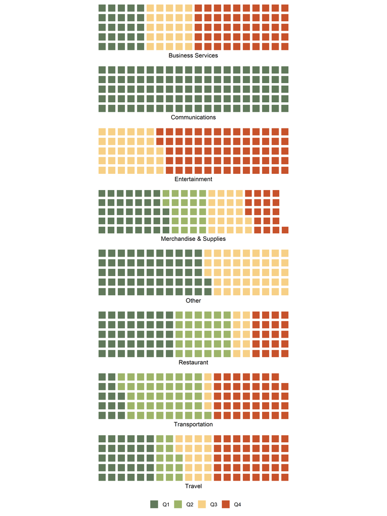

## World Map:

This analysis reveals that the suspect’s movements and international spending activities took place in low-threat states.

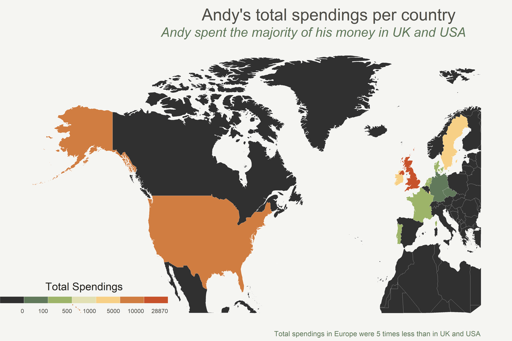

```r
############# MAP

# Creating a vector with the countries that Andy traveled to
europe <- c('UK', 'Luxembourg', 'Germany', 'Sweden', 'Denmark', 'Netherlands', 'Ireland',
            'Czech Republic','Portugal','France', "USA")
# Taking a set with coordinates of all the countries from the library maps
world_map <- map_data('world')

# Transforming our data: calculating total spendings per country, replacing some of the names of the countries
# so that they correspond to the world map dataset with coordinates, joining our data with the world map
# dataset so that we have coordinates for all the countries, filtering longtitude and latitude to zoom in
# Replacing NAs, so that countries Andy didn't spend money in, will be displayed
data_replaced <- df %>%
    group_by(Country) %>%
    summarise(total_spending = sum(Amount)) %>%
    mutate(Country = replace(Country, Country =="United States", "USA")) %>%
    mutate(Country = replace(Country, Country =="United Kingdom", "UK")) %>%
    right_join(world_map, by = c("Country" = "region")) %>%
    filter(lat >= 20, long <= 30) %>%
    mutate(total_spending = replace_na(total_spending, -999))


# Transforming total spendings to a discrete scale
# Here we define equally spaced pretty breaks. They will be surrounded by the minimum value at the beginning
# and the maximum value at the end.

pretty_breaks <- c(0,100,500,1000,5000,10000)
# Find the extremes
minVal <- min(data_replaced$total_spending, na.rm = T)
maxVal <- round((max(data_replaced$total_spending, na.rm = T)),0)
# Compute labels
labels <- c()
brks <- c(minVal, pretty_breaks, maxVal)

for(idx in 1:length(brks)){
  labels <- c(labels,round(brks[idx + 1], 2))
}
labels <- labels[1:length(labels)-1]

# Define a new variable on the data set just as above
data_replaced$brks <- cut(data_replaced$total_spending,
                          breaks = brks,
                          include.lowest = TRUE,
                          labels = labels)
# Set sclaes for our breaks
brks_scale <- levels(data_replaced$brks)
labels_scale <- rev(brks_scale)


# Creating custom theme for the map
theme_map <- function(...) {
  theme_minimal() +
    theme(
      text = element_text(color = "#22211d"),
      axis.line = element_blank(),
      axis.text.x = element_blank(),
      axis.text.y = element_blank(),
      axis.ticks = element_blank(),
      axis.title.x = element_blank(),
      axis.title.y = element_blank(),
      panel.grid.major = element_blank() ,
      panel.grid.minor = element_blank(),
      plot.background = element_rect(fill = "#f5f5f2", color = NA),
      panel.background = element_rect(fill = "#f5f5f2", color = NA),
      panel.border = element_blank(),
      legend.position = c(0.15, 0.1),
      legend.text.align = 0,
      legend.text = element_text(size = 10, hjust = 0, color = "#4e4d47"),
      plot.title = element_text(size = 28, hjust = 0.8, color = "#4e4d47"),
      plot.subtitle = element_text(size = 22, hjust = 0.8, face = "italic", color = "#61795B"),
      legend.title = element_text(size = 18),
      plot.margin = unit(c(.5,.5,.2,.5), "cm"),
      panel.spacing = unit(c(-.1,0.2,.2,0.2), "cm"),
      plot.caption = element_text(size = 12, hjust = 0.92, color = "#61795B"),
      ...
    )
}

# Creating map
(p <- ggplot(data = data_replaced, aes(x = long,
                                       y = lat,
                                       group = group)) +
    # Country polygons
    geom_tile(aes(fill = brks)) +
    scale_alpha(name = "", range = c(0.6, 0), guide = F)  +
    geom_polygon(aes(fill = brks)) +
    # Country outline
    geom_path(data = data_replaced, aes(x = long,
                                        y = lat,
                                        group = group),
              color = "white", size = 0.1) +
    theme_map() +
    labs(x = NULL,
         y = NULL,
         title = "Andy's total spendings per country",
         subtitle = "Andy spent the majority of his money in UK and USA",
         caption = "Total spendings in Europe were 5 times less than in UK and USA" ) +
    scale_fill_manual(
      values = c("#303030", "#61795B","#9DB469", "#E2E0B3", "#F7D086","#D07D41","#C7522B"),
      name = "Total Spendings",
      drop = FALSE,
      guide = guide_legend(
        direction = "horizontal",
        keyheight = unit(4, units = "mm"),
        keywidth = unit(100/length(labels), units = "mm"),
        title.position = 'top',
        title.hjust = 0.5,
        label.hjust = 1,
        nrow = 1,
        byrow = T,
        reverse = F,
        label.position = "bottom"
      )
    ))
```

## Conclusion:

The investigation into Suspect Andy Dusfresne concluded as follows. While some of the suspect’s activities were unusual, the car purchase was the only true outlier in the data. As such, there was not enough evidence to pursue the investigation further, and the case is now closed pending further discrepancies.